# Comparative effectiveness of BNT162b2 vs ChAdOx1-S in CKDq patients

#### Background

Chronic kidney disease (CKD) is a significant risk factor for COVID-19-related mortality. Although vaccination has the potential to mitigate this risk, CKD has been linked with impaired COVID-19 vaccine immunogenicity and high rates of breakthrough infection among individuals who have received a 2-dose primary vaccine series.

Vaccine recommendations for CKD patients in the UK have evolved over time (see [protocol](https://docs.google.com/document/d/1w48W-bCMfn0RdkfxlU6fbRkPv3MnIYd3/edit#heading=h.1fob9te). Relative uptake of different vaccines in this population remains uncertain, as does the relative vaccine effectiveness (VE) of different regimens, including homologous versus heterologous vaccine usage. This project seeks to address these key evidence gaps.

Most CKD patients received a 2-dose homologous primary series of either BNT162b2 or ChAdOx1-S between January and June 2021 (see outputs of vaccine coverage analyses). $~$

#### Inclusion criteria

A total of **1.050e+04** (rounded to the nearest 5) met the inclusion criteria (see *output/data/flowchart.csv* for additional details).  
NB: Dummy data processing flag detected!  
$~$

#### Table 1: Summary of population

| Variable | ChAdOx1-S<sup>1</sup> | BNT162b2<sup>1</sup> |
| --- | --- | --- |
| N |  |  |
| N | 5445 | 5060 |
| Age |  |  |
| 16-69 | 3820 (70.2%) | 3575 (70.7%) |
| 70-79 | 1285 (23.6%) | 1135 (22.4%) |
| 80-89 | 275 (5.1%) | 285 (5.6%) |
| 90+ | 65 (1.2%) | 65 (1.3%) |
| Sex |  |  |
| Female | 2830 (52%) | 2640 (52.2%) |
| Male | 2620 (48.1%) | 2420 (47.8%) |
| Ethnicity |  |  |
| White | 1080 (19.8%) | 950 (18.8%) |
| Mixed | 995 (18.3%) | 1025 (20.3%) |
| Asian or Asian British | 1055 (19.4%) | 920 (18.2%) |
| Black or Black British | 1025 (18.8%) | 950 (18.8%) |
| Other ethnic groups | 1025 (18.8%) | 980 (19.4%) |
| Unknown | 265 (4.9%) | 235 (4.6%) |
| IMD |  |  |
| 1 most deprived | 1115 (20.5%) | 1015 (20.1%) |
| 2 | 1125 (20.7%) | 1040 (20.6%) |
| 3 | 1075 (19.7%) | 1045 (20.7%) |
| 4 | 1130 (20.8%) | 980 (19.4%) |
| 5 least deprived | 1000 (18.4%) | 975 (19.3%) |
| Region |  |  |
| London | 1080 (19.8%) | 1030 (20.4%) |
| East of England | 555 (10.2%) | 500 (9.9%) |
| East Midlands | 535 (9.8%) | 485 (9.6%) |
| North East | 565 (10.4%) | 555 (11%) |
| North West | 540 (9.9%) | 475 (9.4%) |
| South East | 570 (10.5%) | 485 (9.6%) |
| South West | 555 (10.2%) | 495 (9.8%) |
| West Midlands | 550 (10.1%) | 525 (10.4%) |
| Yorkshire and the Humber | 495 (9.1%) | 505 (10%) |
| JCVI group |  |  |
| 2 (80+ or health/social care worker) | 340 (6.2%) | 350 (6.9%) |
| 3 (75+) | 260 (4.8%) | 200 (4%) |
| 4 (70+ or clinically extremely vulnerable) | 1740 (32%) | 1505 (29.7%) |
| 5 (65+) | 220 (4%) | 235 (4.6%) |
| 6 (16-65 and clinically vulnerable) | 2885 (53%) | 2770 (54.7%) |
| Setting |  |  |
| Urban conurbation | 1385 (25.4%) | 1205 (23.8%) |
| Urban city or town | 1390 (25.5%) | 1270 (25.1%) |
| Rural town or village | 2675 (49.1%) | 2585 (51.1%) |
| Clinical (CKD-related) |  |  |
| CKD diagnostic code | 1085 (19.9%) | 1045 (20.7%) |
| Dialysis | 2940 (54%) | 2755 (54.4%) |
| Kidney transplant | 2985 (54.8%) | 2825 (55.8%) |
| CKD stage 3-5 code | 1110 (20.4%) | 1005 (19.9%) |
| Other |  |  |
| Clinically extremely vulnerable | 1690 (31%) | 1485 (29.3%) |
| Care home resident | [Redacted] | [Redacted] |
| Health and social care worker | [Redacted] | [Redacted] |
| End of life care | [Redacted] | [Redacted] |
| Housebound | [Redacted] | [Redacted] |
| Current or former smoker | 770 (14.1%) | 710 (14%) |
| Asthma | 1060 (19.5%) | 975 (19.3%) |
| High or elevated blood pressure | [Redacted] | [Redacted] |
| Immunosuppression | 1900 (34.9%) | 1795 (35.5%) |
| Chronic respiratory disease | 1135 (20.8%) | 945 (18.7%) |
| Diabetes | 1090 (20%) | 1000 (19.8%) |
| Chronic liver disease | 1065 (19.6%) | 1015 (20.1%) |
| Chronic heart disease | 1100 (20.2%) | 990 (19.6%) |
| Asplenia | 1085 (19.9%) | 1000 (19.8%) |
| Cancer | 1105 (20.3%) | 1045 (20.7%) |
| Haematologic cancer | 1135 (20.8%) | 995 (19.7%) |
| Obesity | 1625 (29.8%) | 1505 (29.7%) |
| Chronic neurological disease (including learning disability) | 1055 (19.4%) | 1000 (19.8%) |
| Severe mental illness | 1085 (19.9%) | 995 (19.7%) |
| Organ transplant (non-kidney) | 1025 (18.8%) | 985 (19.5%) |
| Prior COVID | 235 (4.3%) | 225 (4.4%) |
| Time between doses 1 and 2 |  |  |
| 10-14 weeks | 2700 (49.6%) | 2575 (50.9%) |
| 14 weeks or more | 2745 (50.4%) | 2480 (49%) |

<sup>*1*</sup> All counts rounded to nearest 5; any rounded counts <=10 or within <=10 of population total redacted.

$~$

#### Crude incidence rate ratios in two groups

| Period (days) | BNT162b2 n, BNT (total) | BNT162b2 n, BNT (events) | BNT162b2 person-years, BNT | BNT162b2 rate, BNT | ChAdOx1-S n, AZ (total) | ChAdOx1-S n, AZ (events) | ChAdOx1-S person-years, AZ | ChAdOx1-S rate, AZ | IRR<sup>1</sup> |  |
| --- | --- | --- | --- | --- | --- | --- | --- | --- | --- | --- |
| Positive SARS-CoV-2 test |  |  |  |  |  |  |  |  |  |  |
| 1-56 | 5059 | [Redacted] | 775.0 | [Redacted] | 5447 | [Redacted] | 834.6 | [Redacted] |  | -- |
| 57-112 | 5051 | 20 | 718.1 | 0.028 | 5440 | 28 | 773.1 | 0.036 | 1.29 (0.71-2.44) |  |
| 113-168 | 3533 | 58 | 366.1 | 0.158 | 3828 | 68 | 394.5 | 0.172 | 1.09 (0.76-1.57) |  |
| 169-224 | 1915 | 100 | 187.3 | 0.534 | 2065 | 102 | 204.4 | 0.499 | 0.93 (0.70-1.24) |  |
| 225-280 | 307 | [Redacted] | 7.0 | [Redacted] | 366 | [Redacted] | 8.0 | [Redacted] | -- |  |
| All | 5059 | 184 | 2053.4 | 0.09 | 5447 | 204 | 2214.7 | 0.092 | 1.02 (0.84-1.26) |  |
| COVID-related A&E admission |  |  |  |  |  |  |  |  |  |  |
| 1-56 | 5059 | 41 | 771.9 | 0.053 | 5447 | 38 | 832.3 | 0.046 | 0.87 (0.54-1.37) |  |
| 57-112 | 5013 | 42 | 710.7 | 0.059 | 5403 | 45 | 767.0 | 0.059 | 1.00 (0.64-1.55) |  |
| 113-168 | 3487 | 21 | 362.2 | 0.058 | 3796 | 25 | 393.3 | 0.064 | 1.10 (0.59-2.06) |  |
| 169-224 | 1915 | 13 | 189.3 | 0.069 | 2087 | 12 | 208.6 | 0.058 | 0.84 (0.35-1.99) |  |
| 225-280 | 316 | 0 | 7.3 | 0 | 378 | 0 | 8.1 | 0 | NA (NA-NA) |  |
| All | 5059 | 117 | 2041.4 | 0.057 | 5447 | 120 | 2209.3 | 0.054 | 0.95 (0.73-1.23) |  |
| COVID-related hospitalisation |  |  |  |  |  |  |  |  |  |  |
| 1-56 | 5059 | 50 | 771.3 | 0.065 | 5447 | 30 | 832.6 | 0.036 | 0.55 (0.34-0.89) |  |
| 57-112 | 5004 | 46 | 709.2 | 0.065 | 5411 | 51 | 766.8 | 0.067 | 1.03 (0.67-1.56) |  |
| 113-168 | 3481 | 19 | 361.8 | 0.053 | 3792 | 20 | 394.0 | 0.051 | 0.96 (0.49-1.91) |  |
| 169-224 | 1916 | 13 | 189.2 | 0.069 | 2096 | 8 | 210.0 | 0.038 | 0.55 (0.20-1.44) |  |
| 225-280 | 316 | 0 | 7.3 | 0 | 388 | [Redacted] | 8.3 | [Redacted] | -- |  |
| All | 5059 | 128 | 2038.9 | 0.063 | 5447 | 110 | 2211.7 | 0.05 | 0.79 (0.61-1.03) |  |
| COVID-related death |  |  |  |  |  |  |  |  |  |  |
| 1-56 | 5059 | 13 | 774.2 | 0.017 | 5447 | 21 | 833.0 | 0.025 | 1.47 (0.72-3.26) |  |
| 57-112 | 5041 | 17 | 716.6 | 0.024 | 5420 | 25 | 770.6 | 0.032 | 1.33 (0.71-2.70) |  |
| 113-168 | 3530 | [Redacted] | 368.5 | [Redacted] | 3817 | 15 | 395.5 | 0.038 | -- |  |
| 169-224 | 1962 | [Redacted] | 193.9 | [Redacted] | 2107 | [Redacted] | 211.3 | [Redacted] | -- |  |
| 225-280 | 325 | 0 | 7.5 | 0 | 384 | 0 | 8.2 | 0 | NA (NA-NA) |  |
| All | 5059 | 39 | 2060.6 | 0.019 | 5447 | 65 | 2218.7 | 0.029 | 1.53 (1.03-2.36) |  |

<sup>*1*</sup> IRR = incidence rate ratio. Data redacted for any rounded counts of >0 and <=5

$~$

#### Hazard ratios over time (figure)

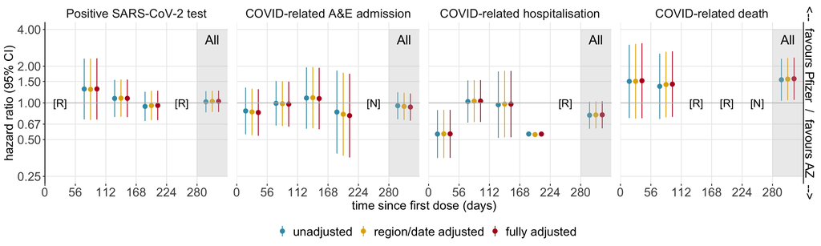

[R] = redacted (between 1 and 5 events in either vaccine group); [N] = 0 events in both vaccine groups. $~$

#### Hazard ratios over time (table)

| Period (days) | unadjusted | region/date adjusted | fully adjusted |
| --- | --- | --- | --- |
| Positive SARS-CoV-2 test |  |  |  |
| 1-56 | -- | -- | -- |
| 57-112 | 1.3 (0.73-2.31) | 1.29 (0.72-2.3) | 1.3 (0.73-2.32) |
| 113-168 | 1.09 (0.77-1.54) | 1.09 (0.77-1.55) | 1.09 (0.76-1.55) |
| 169-224 | 0.94 (0.71-1.23) | 0.95 (0.72-1.25) | 0.95 (0.72-1.26) |
| 225-280 | -- | -- | -- |
| All | 1.02 (0.84-1.25) | 1.03 (0.84-1.26) | 1.03 (0.84-1.26) |
| COVID-related A&E admission |  |  |  |
| 1-56 | 0.86 (0.55-1.34) | 0.84 (0.54-1.31) | 0.83 (0.54-1.3) |
| 57-112 | 0.99 (0.65-1.51) | 0.99 (0.65-1.5) | 0.98 (0.64-1.49) |
| 113-168 | 1.1 (0.61-1.96) | 1.1 (0.62-1.97) | 1.09 (0.61-1.94) |
| 169-224 | 0.84 (0.38-1.84) | 0.81 (0.37-1.76) | 0.79 (0.36-1.73) |
| 225-280 | -- | -- | -- |
| All | 0.95 (0.73-1.22) | 0.94 (0.73-1.21) | 0.92 (0.72-1.19) |
| COVID-related hospitalisation |  |  |  |
| 1-56 | 0.56 (0.35-0.87) | 0.56 (0.35-0.88) | 0.56 (0.35-0.88) |
| 57-112 | 1.03 (0.69-1.53) | 1.03 (0.7-1.54) | 1.04 (0.7-1.54) |
| 113-168 | 0.97 (0.52-1.81) | 0.98 (0.52-1.83) | 0.98 (0.52-1.83) |
| 169-224 | 0.56 (0.23-1.34) | 0.55 (0.23-1.34) | 0.56 (0.23-1.36) |
| 225-280 | -- | -- | -- |
| All | 0.79 (0.61-1.02) | 0.8 (0.62-1.03) | 0.8 (0.62-1.03) |
| COVID-related death |  |  |  |
| 1-56 | 1.5 (0.75-3) | 1.5 (0.74-3.04) | 1.52 (0.75-3.08) |
| 57-112 | 1.37 (0.74-2.53) | 1.41 (0.76-2.62) | 1.42 (0.77-2.65) |
| 113-168 | -- | -- | -- |
| 169-224 | -- | -- | -- |
| 225-280 | -- | -- | -- |
| All | 1.55 (1.04-2.3) | 1.57 (1.05-2.33) | 1.58 (1.06-2.35) |